# Advanced Lane Finding Project

## 1. Purpose:

The goals / steps of this project are the following:

- Compute the camera calibration matrix and distortion coefficients given a set of chessboard images.
- Apply a distortion correction to raw images.
- Use color transforms, gradients, etc., to create a thresholded binary image.
- Apply a perspective transform to rectify binary image ("birds-eye view").
- Detect lane pixels and fit to find the lane boundary.
- Determine the curvature of the lane and vehicle position with respect to center.
- Warp the detected lane boundaries back onto the original image.
- Output visual display of the lane boundaries and numerical estimation of lane curvature and vehicle position.

```python
# import neccessary package
import numpy as np
import cv2
import matplotlib.pyplot as plt
import glob
import pickle
import os
from moviepy.editor import VideoFileClip
from IPython.display import HTML
import matplotlib.image as mpimg
```

## 2. Data Preparation

Image distortion occurs when a camera looks at 3D objects in the real world and transforms them into a 2D image; this transformation isn’t perfect. Distortion actually changes what the shape and size of these 3D objects appear to be.

So, the first step in analyzing camera images, is to calibrate our camera using the twenty provided chessboard images (see section 3 below). Then, I can analyze camera images by undo this distortion so that I can get correct and useful information out of them. I can test the undo distortion of images by using the eight test images provided in the test_images folder.

## 3. Camera Calibration and Image Undistortion

Below is the camera_calibration function which describe how I can calibrate our camera. In this function, for each of the twenty chessboard images, I first convert it to the grayscale and find the chessboard corners for each of the chessboard image.

I start by preparing "object points", which will be the (x, y, z) coordinates of the chessboard corners in the world. Here I am assuming the chessboard is fixed on the (x, y) plane at z=0, such that the object points are the same for each calibration image. Thus, `objp` is just a replicated array of coordinates, and `objpoints` will be appended with a copy of it every time I successfully detect all chessboard corners in a test image. `imgpoints` will be appended with the (x, y) pixel position of each of the corners in the image plane with each successful chessboard detection.

I then used the output `objpoints` and `imgpoints` to compute the camera calibration and distortion coefficients using the `cv2.calibrateCamera()` function.

Finally, I can save the Camera Matrix (mtx) and Distortion Coefficient (dist) into a dictionary and save them as a pickle file for later use.

```python
# function to calibration the vehicle camera
def camera_calibration(image_directory, cal_image):
    objp = np.zeros((6 * 9, 3), np.float32)
    objp[:, :2] = np.mgrid[0:9, 0:6].T.reshape(-1, 2)
    objpoints = []  # 3d points in real world space
    imgpoints = []  # 2d points in image plane.
    images = glob.glob(image_directory)

    # loop over each image in the image_directory
    for idx, fname in enumerate(images):
        img = cv2.imread(fname)
        gray = cv2.cvtColor(img, cv2.COLOR_BGR2GRAY)

        # Find the chessboard corners
        ret, corners = cv2.findChessboardCorners(gray, (9, 6), None)

        # If found, add object points, image points
        if ret == True:
            objpoints.append(objp)
            imgpoints.append(corners)

            # Draw and display the corners
            cv2.drawChessboardCorners(img, (9, 6), corners, ret)
            cv2.imshow('img', img)
            cv2.waitKey(500)

    # Do camera calibration on a given test image
    img = cv2.imread(cal_image)
    img_size = (img.shape[1], img.shape[0])
    ret, mtx, dist, rvecs, tvecs = cv2.calibrateCamera(objpoints, imgpoints, img_size, None, None)

    # Save the camera calibration result (mtx, dist) in the dictionary for late use
    dist_pickle = {}
    dist_pickle['mtx'] = mtx
    dist_pickle['dist'] = dist
    pickle.dump(dist_pickle, open('camera_cal.p', 'wb'))
    #plt.show()
    return mtx, dist
```

After camera calibration and determining the camera matrix and distortion coeffcient, I can use these information to undistort the road test_image.

The undistortion function below first will check to see if the saved pickle_file already existed. If it is existed, all I need to do is to load the camera matrix (mtx) and distortion coefficient (dist). If the saved pickle file not existed, I will need to calibrate camera to determine the mtx and dist prior to undo any image distortion on the test images.

The un-distorted image then is saved in the output_images for later review. I can view and compare the original and un-distortion image by providing a 'yes' in the print_flag option as shown below.

```python
# After calibration the vehicle camera, use this function to undistort images
def undistortion (image, pickle_file, print_flag = None, image_directory = None, cal_image = None):
    # check to see if the pickle_file already existed, then load camera calibration parameters
    if os.path.isfile(pickle_file):
        dist_pickle = pickle.load(open(pickle_file, 'rb'))
        mtx = dist_pickle['mtx']
        dist = dist_pickle['dist']
    else:
        # if there is no pickle_file, do the camera calibration
        mtx, dist = camera_calibration(image_directory,cal_image)
    img = cv2.imread(image)
    dst = cv2.undistort(img, mtx, dist, None, mtx)
    # write a undistorted image on a file
    cv2.imwrite('output_images/undistored_image.jpg', dst)

    if print_flag == 'yes':
        # Visualize undistortion
        f, (ax1, ax2) = plt.subplots(1, 2, figsize=(20, 10))
        ax1.imshow(img, cmap='gray')
        ax1.set_title('Original Image', fontsize=10)
        ax2.imshow(dst, cmap='gray')
        ax2.set_title('Undistorted Image', fontsize=10)
        plt.show()
    return dst
```

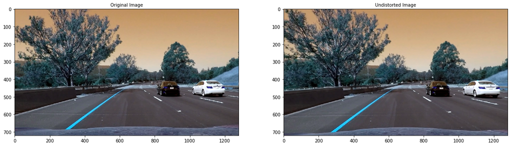

```python
# camera calibration
# image_directory = 'camera_cal/*.jpg'
# cal_image = 'camera_cal/calibration4.jpg'
# mtx, dist = camera_calibration(image_directory,cal_image)

# Undistort the test image
test_image = 'test_images/test6.jpg'
pickle_file = 'camera_cal.p'
dst = undistortion(test_image,pickle_file, print_flag= 'yes')
```

## 4. Gradient and Color Threshold

Below are function definition of the Gradient and Color Threshold techniques which I am going to use in this project.

- DIRECTION OF THE GRADIENT:

In this function, I use bilateral filter technique after converting images to grayscale to filter out noises while still preserving good edges from the images. Finally, I compute the direction of the gradient and apply threshold. The direction of the gradient is more noisier than other gradient techniques, but I can pick up certain features by orientation. The function to describe the direction of the gradient is implemented in the function **dir_threshold()** below.

- SOBEL OPERATOR:

Sobel operator is a technique which take the derivative of images in x and y direction. Depend on a provided kernel size in odd numbers, the greater the kernel size, the smoother gradient applies to the images.

As you can see the Sobel operator in x direction tends to filter out horizontal edges and noises while preserve vertical edges in the lane lines. In contrast, the Sobel operator in y direction tends to keep horizontal edges and noises which may not be applicable to this lane line detection.

As in direction of the gradient technique, I also use the bilateral filter after converting images to grayscale to filter out noises while still preserve good edges from the images. Finally, after computing the sobel operation in the x or y direction, I then apply the threshold to pick up particular features I want. The function to describe the Sobel operator is implemented in the function **apply_sobel()** below.

- MAGNITUDE OF THE GRADIENT:

This is a technique to combine and compute the magnitude of both gradient in both x and y direction. As like any other gradient operation, I can choose different kernel sizes to experiment the image output, again the greater the kernel size, the smoother gradient applies to the images. Finally, I also apply threshold to pick up particular features I want. The function to describe the magnitude of the gradient is implemented in the function **mag_thresh()** below

- HLS and HSV COLOR THRESHOLD:

Although gradient threshold can pick up the certain features very well; however, one of the limitation of the gradient threshold is that it purely picks up edges under shadows and specially, the yellow-color lane line on the road because it needs to covert to the grayscale which destroys most of the useful information of the color. There are many different technique to preserve the color information. In this project, I use the HLS and HSV color space. HSV color space (hue, saturation, and value), and HLS space (hue, lightness, and saturation) are some of the most commonly used color spaces in image analysis. Among the H,L,S channels in HLS and H,S,V channels in HSV color space, the S-channel picks up the line very well as compared to other channels, so in this project, I'm going to use the S-channel in both HLS and HSV and apply the threshold to pick up the lane line. The functions to describe the HSL and HSV color threshold are implmented in the function **apply_hls_color_threshold()** and **apply_hsv_color_threshold()** respectively below.

- COMBINED THRESHOLD:

To pick up all/most of the verticle lane line under different conditions like shadows and yellow/other color lane line, one of the best technique in computer vision is to experiment and combine the above techniques. In this project, this combination **combined_sobelx_hls_binary[(sobelx_binary == 1 | ((mag_binary == 1) & (direction_binary == 1))) | hls_binary == 1] = 1** tends to give me the best result to dectect the lane line. The function to describe this combined technique is implemented in the function **combined_threshold()**.

In this function I also apply the mask out technique in computer vision to filter out road noise inside the lane line. In this technique, I determine the ROI region and use the function **cv2.fillPoly(combined_sobelx_hls_binary, np.array([src], np.int32), 0)** to filter out the noises. Lastly, this function also implement a print_flag option to print out all possible gradient and color threshold images for comparation.

### (a). Function definition

```python
# Define a function to threshold an image for a given range and Sobel kernel
def dir_threshold(image, sobel_kernel=3, thresh=(0, np.pi / 2)):
    # convert to grayscale
    gray = cv2.cvtColor(image, cv2.COLOR_RGB2GRAY)
    # use bilateral filter to filter out noises while preserve edges of images
    gray = cv2.bilateralFilter(gray,5,9,9)

    # Calculate the x and y gradients
    sobelx = cv2.Sobel(gray, cv2.CV_64F, 1, 0, ksize=sobel_kernel)
    sobely = cv2.Sobel(gray, cv2.CV_64F, 0, 1, ksize=sobel_kernel)

    # Take the absolute value of the gradient direction,
    # apply a threshold, and create a binary image result
    absgraddir = np.arctan2(np.absolute(sobely), np.absolute(sobelx))
    binary_direction = np.zeros_like(absgraddir)
    binary_direction[(absgraddir >= thresh[0]) & (absgraddir <= thresh[1])] = 1

    # Return the binary image
    return binary_direction


# Define a sobel function that takes an image, gradient orientation,
# and threshold min / max values.
def apply_sobel (image, orient='x', sobel_threshmin = 0, sobel_threshmax = 100, sobel_kernel = 3):
    # Convert to grayscale
    gray = cv2.cvtColor(image, cv2.COLOR_BGR2GRAY)
    # use bilateral filter to filter out noises while preserve edges of images
    gray = cv2.bilateralFilter(gray,5,9,9)

    # Depend on the given orientation, select the right orient
    if orient == 'x':
        sobelx = cv2.Sobel(gray, cv2.CV_64F, 1, 0, ksize= sobel_kernel)
        abs_sobelx = np.absolute(sobelx)
        scaled_sobelx = np.uint8(255 * abs_sobelx / np.max(abs_sobelx))
        scaled_sobel = scaled_sobelx

    elif orient == 'y':
        sobely = cv2.Sobel(gray, cv2.CV_64F, 0, 1, ksize= sobel_kernel)
        abs_sobely = np.absolute(sobely)
        scaled_sobely = np.uint8(255 * abs_sobely / np.max(abs_sobely))
        scaled_sobel = scaled_sobely

    sobel_binary = np.zeros_like(scaled_sobel)
    sobel_binary[(scaled_sobel >= sobel_threshmin) & (scaled_sobel <= sobel_threshmax)] = 1
    return sobel_binary

# Define a function to return the magnitude of the gradient
# for a given sobel kernel size and threshold values
def mag_thresh(img, sobel_kernel=3, mag_thresh=(0, 255)):
    # Convert to grayscale
    gray = cv2.cvtColor(img, cv2.COLOR_RGB2GRAY)
    # use bilateral filter to filter out noises while preserve edges of images
    gray = cv2.bilateralFilter(gray,5,9,9)

    # Take both Sobel x and y gradients
    sobelx = cv2.Sobel(gray, cv2.CV_64F, 1, 0, ksize=sobel_kernel)
    sobely = cv2.Sobel(gray, cv2.CV_64F, 0, 1, ksize=sobel_kernel)

    # Calculate the gradient magnitude
    gradmag = np.sqrt(sobelx**2 + sobely**2)

    # Rescale to 8 bit
    scale_factor = np.max(gradmag)/255
    gradmag = (gradmag/scale_factor).astype(np.uint8)

    # Create a binary image of ones where threshold is met, zeros otherwise
    mag_binary = np.zeros_like(gradmag)
    mag_binary[(gradmag >= mag_thresh[0]) & (gradmag <= mag_thresh[1])] = 1

    return mag_binary

# Define a function to return the color threshold for a given S-channel of HLS color space
def apply_hls_color_threshold (image, hls_threshmin=0, hls_threshmax=100):
    hls = cv2.cvtColor(image, cv2.COLOR_RGB2HLS)
    # use bilateral filter to filter out noises while preserve edges of images
    hls = cv2.bilateralFilter(hls,5,9,9)
    h = hls[:,:,0]
    l = hls[:,:,1]
    s = hls[:,:,2]
    hls_binary = np.zeros_like(s)
    # Create a binary image of ones where threshold is met, zeros otherwise
    hls_binary[(s > hls_threshmin) & (s <= hls_threshmax)] = 1
    return  hls_binary

# Define a function to return the color threshold for a given S-channel of HSV color space
def apply_hsv_color_threshold (image, hsv_threshmin=0, hsv_threshmax=100):
    hsv = cv2.cvtColor(image, cv2.COLOR_RGB2HSV)
    # use bilateral filter to filter out noises while preserve edges of images
    hsv = cv2.bilateralFilter(hsv,5,9,9)
    h = hsv[:,:,0]
    s = hsv[:,:,1]
    v = hsv[:,:,2]
    hsv_binary = np.zeros_like(s)
    # Create a binary image of ones where threshold is met, zeros otherwise
    hsv_binary[(s > hsv_threshmin) & (s <= hsv_threshmax)] = 1
    return hsv_binary

# Define a function to combine different binary images
def combined_threshold (image, print_flag = None):
    # Define the region of interest so that later will be use to  mask out
    # the texture inside the lane.
    img_size = np.shape(image)
    halfTop = np.uint(img_size[0] / 1.5)
    halfBottom = np.uint(img_size[0])
    center = np.uint(img_size[1] / 2)
    TopLeft = np.uint(center - 0.05 * (img_size[1] / 2))
    TopRight = np.uint(center + 0.05 * (img_size[1] / 2))
    BottomLeft = np.uint(center - 0.5 * (img_size[1] / 2))
    BottomRight = np.uint(center + 0.7 * (img_size[1] / 2))
    src = np.float32([[TopLeft, halfTop], [TopRight, halfTop], [BottomRight, halfBottom], [BottomLeft, halfBottom]])

    sobelx_binary = apply_sobel(image, 'x', sobel_threshmin=20, sobel_threshmax=100, sobel_kernel=3)
    sobely_binary = apply_sobel(image, 'y', sobel_threshmin=20, sobel_threshmax=100, sobel_kernel=3)
    direction_binary = dir_threshold(image,sobel_kernel=15, thresh=(0.7, 1.3))
    hls_binary = apply_hls_color_threshold(image,hls_threshmin=180, hls_threshmax=255)
    hsv_binary = apply_hsv_color_threshold(image, hsv_threshmin=180, hsv_threshmax=255)
    mag_binary = mag_thresh(image,sobel_kernel=3,mag_thresh=(50,255))

    combined_sobelx_hls_binary = np.zeros_like(sobelx_binary)
    #combined_sobelx_hls_binary[(sobelx_binary == 1) | (hls_binary == 1)] = 1
    combined_sobelx_hls_binary[(sobelx_binary == 1 | ((mag_binary == 1) & (direction_binary == 1))) | hls_binary == 1] = 1

    # mask out texture inside the lane
    cv2.fillPoly(combined_sobelx_hls_binary, np.array([src], np.int32), 0)

    # plot 6 different gradient and color threshold technique on a given test image
    if print_flag == 'yes':
        plt.figure('Test Images', figsize=(20,10))
        plt.subplot(2,3,1)
        plt.title('sobel x image')
        plt.imshow(sobelx_binary, cmap='gray')

        plt.subplot(2, 3, 2)
        plt.title('sobel y image')
        plt.imshow(sobely_binary, cmap='gray')

        plt.subplot(2, 3, 3)
        plt.title('sobel direction')
        plt.imshow(direction_binary, cmap='gray')

        plt.subplot(2, 3, 4)
        plt.title('hls threshold image')
        plt.imshow(hls_binary, cmap='gray')

        plt.subplot(2, 3, 5)
        plt.title('hsv threshold image')
        plt.imshow(hsv_binary, cmap='gray')

        plt.subplot(2, 3, 6)
        plt.title('combined sobelx and hls image')
        plt.imshow(combined_sobelx_hls_binary, cmap='gray')
        plt.show()
    return combined_sobelx_hls_binary, sobelx_binary, mag_binary, direction_binary, hls_binary

# Define a function to apply the combined gradient and color threshold technique on eight
# test images in the test_image_directory
def test_image_binaries(test_image_directory, pickle_file):
    list_combined_binary = []
    images = glob.glob(test_image_directory)
    for i, image in enumerate(images):
        dst = undistortion(image,pickle_file, print_flag = None)
        combined_sobelx_hls_binary, sobelx_binary, mag_binary, direction_binary, hls_binary \
        = combined_threshold(dst)
        list_combined_binary.append(combined_sobelx_hls_binary)
        plt.figure('Eight Test Images', figsize=(20,10))
        plt.subplot(2,4, i+1)
        plt.title('Image: test%s.jpg'%str(i+1))
        plt.imshow(combined_sobelx_hls_binary, cmap='gray')
    plt.show()
    return list_combined_binary
```

### (b). Gradient and Color Threshold Visualization

Below are the plots of different gradient and color threshold of the test_image test6.jpg. As you can see, the combined threshold technique really gives best visualization.

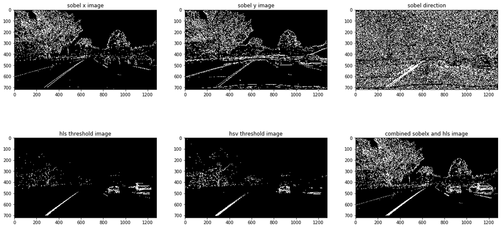

```python
# Apply gradient and color threshold on the test image
combined_sobelx_hls_binary = combined_threshold(dst, print_flag='yes')
```

Below are plots to apply the combined_threshold method to all the eight test_images. The function **test_image_binaries()** applies the un-distortion and combine threshold method for each of the eight test images as shown below

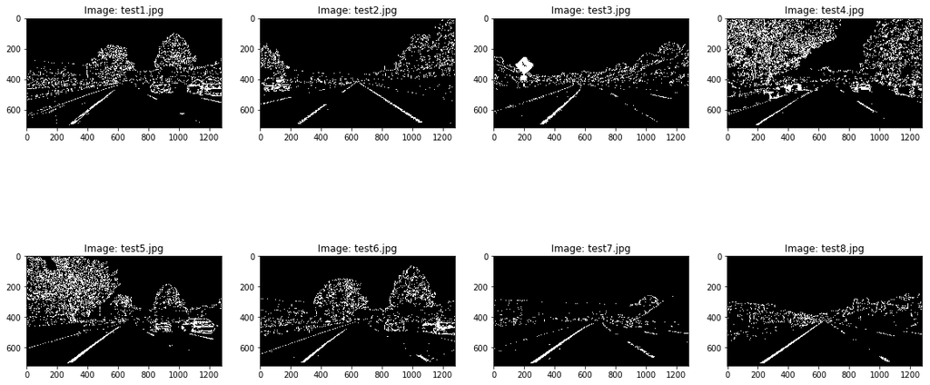

```python
# Apply combined gradient and color threshold on different images
test_image_directory = 'test_images/*.jpg'
list_combined_binary = test_image_binaries(test_image_directory,pickle_file)
```

## 3. Perspective Transform

After applying a distortion correction to raw images and use color transforms, gradients to create a thresholded binary image. In this section, I'm going to perform perspective transform to rectify binary image.

The first step to perform perspective transform is to determine the region of interest on the images. This ROI is described in the function **boundRectangle()** below. In this boundRectangle() function, I determine the coordinates of the four points and draw lines around these four points for the source and destination to apply perspective transform.

Use these four points of the source and destination, I then use computer vision function cv2.getPerspectiveTransform() to calculate the Matrix M. This matrix M later can be used in the cv2.warpPerspective() to perform the bird-eye view on images.

```python
# Define a region of interest of lane line to apply perspective transform
def boundRectangle(image):
    # Define a region of interest of lane line to apply perspective transform
    img_size = np.shape(image)
    halfTop = np.uint(img_size[0] / 1.5)
    halfBottom = np.uint(img_size[0])
    center = np.uint(img_size[1] / 2)
    TopLeft = np.uint(center - 0.15 * (img_size[1] / 2))
    TopRight = np.uint(center + 0.25 * (img_size[1] / 2))
    BottomLeft = np.uint(center - 0.9 * (img_size[1] / 2))
    BottomRight = np.uint(center + 1.1 * (img_size[1] / 2))
    cv2.line(image,(TopLeft,halfTop),(TopRight, halfTop),(0,255,0),2)
    cv2.line(image, (TopRight, halfTop), (BottomRight, halfBottom), (0, 255, 0), 6)
    cv2.line(image, (BottomRight, halfBottom), (BottomLeft, halfBottom), (0, 255, 0), 6)
    cv2.line(image, (BottomLeft, halfBottom), (TopLeft, halfTop), (0, 255, 0), 6)

    # Choose the four points for source and destination to apply perspective transform
    src = np.float32([[TopLeft, halfTop], [TopRight, halfTop], [BottomRight, halfBottom], [BottomLeft, halfBottom]])
    dst = np.float32([[0, 0], [img_size[1], 0], [img_size[1], img_size[0]], [0, img_size[0]]])

    return src,dst, image

# Define a perspective transform to warp images in bird-eye view, and plot them
def perspective_transform(image, print_flag = None, figsize = None):
    src, dst, img = boundRectangle(image)
    M = cv2.getPerspectiveTransform(src, dst)
    M_inv = cv2.getPerspectiveTransform(dst, src)
    warped = cv2.warpPerspective(image, M, (image.shape[1], image.shape[0]), flags=cv2.INTER_LINEAR)
    unwarped = cv2.warpPerspective(warped, M_inv, (warped.shape[1], warped.shape[0]), flags=cv2.INTER_LINEAR)

    # Visualize
    if print_flag == 'yes':
        plt.figure(figsize=figsize)
        plt.subplot(1,3,1)
        plt.title('Original binary')
        plt.imshow(img, cmap='gray')

        plt.subplot(1, 3, 2)
        plt.title('bird-eye view')
        plt.imshow(warped, cmap='gray')
        plt.show()
    return warped, M, unwarped, M_inv

# Define a function to plot bird-eye view for a list of images
def bird_eye_view (list_combined_binary, figsize=None):
    for image in list_combined_binary:
        warped = perspective_transform(image,print_flag='yes', figsize=figsize)
        cv2.waitKey(500)
```

Below are plots when calling the function **perspective_transform()**. As you can see from the original image on the left below, the trapezoid shape is drawn around the ROI. On the right is the bird-eye view after applying the perspective transform.

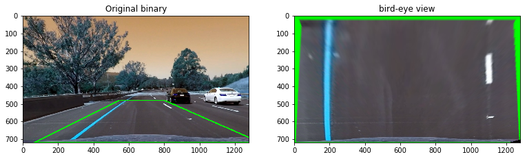

```python
# Draw a region of interest box and warp the test image for bird-eye view
warped = perspective_transform(dst, print_flag='yes', figsize=(20,40))
```

Bird-eye view of the 8 test images in the test_image folder. This can be done by calling the function **bird_eye_view()** above.

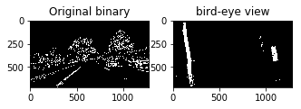

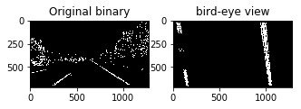

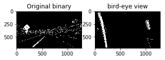

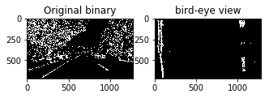

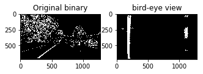

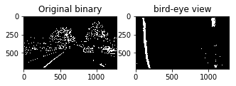

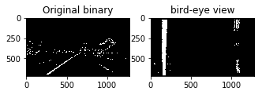

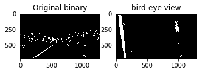

```python
bird_eye_view(list_combined_binary, figsize=(8,4))
```

## 4. Finding Lane

### (a). Calculate Lane Line, Lane Curvature and vehicle position

#### Calculate Lane Line:

The steps to calculate the lane line is described in the function **Advanced_Lane_Line()** below. After obtaining the bird-eye view of the combined gradient and threshold binary image, I take the histogram of the bottom half of the image. This information can help me to find the peak of the left and right halves of the histogram which is the starting point for the left and right lines.

After determining the starting point for the left and right lane lines, I then perform the window search technique on both left and right lane lines to identify x,y position of all the nonzero pixels. In this window search technique, I define nine sliding windows and perform the window search for nonzero pixels for the left and right lane lines for each of these 9 sliding window and apply the second order polynomial to determine the best fit line for left and right lane lines. Finally, all of the best line fit are stored in the lane_map dictionary which can be return for later use.

#### Calculate Lane Curve:

Given the lane_map dictionary which stored the best fit parameters for the left and right lane lines, I can compute the lane curvature using the tutorial **http://www.intmath.com/applications-differentiation/8-radius-curvature.php**. The steps to compute the lane curvature is in the function **calculate_lane_curve()** below. For transforming in the x direction, I start with the assumption that the lane is 3.7 meters wide, and divide by the width of the lane in my warped image. From looking at the image in the previous rubric section, it looks like the lines are about 900 pixels apart, so a more appropriate conversion would be to use xm_per_pix = 3.7/900.

Additionally, in the y direction, I can estimate this by assuming that each white dash is 3 meters long, and counting how many white dashes would fit in the warped image from bottom to top. If I decide that it is only 15 meters (just a random example) then ym_per_pix = 15 / 720.

#### Vehicle offset postion:

Given the lane_map dictionary which stored the best fit parameters for the left and right lane line, I can again compute the vehicle offset position **vehicle_position = image.shape[1] / 2 - (bottom_x_left + bottom_x_right) / 2**. The steps to compute the vehicle offset position is described in the function **calculate_vehicle_position()** below.

#### A function to draw color map on road:

Once I have a good measurement of the line positions in warped space, it's time to project my measurement back down onto the road. The steps to describe how to project the measurements back down onto the road is in the function **drawing()**. In this function, I define the y-points to draw color map. I then fit the left and right lane in second order polynomial curve to determine the best fit lines. I then find the point coordinates on left and right lanes and aplly the yellow to the coordinate points. Finally, I unwarp back to the original images.

```python
# Define a function to calculate lane line
def Advanced_Lane_Line(binary_warped):
    # Assuming you have created a warped binary image called "binary_warped"
    # Take a histogram of the bottom half of the image
    histogram = np.sum(binary_warped[np.uint(binary_warped.shape[0] // 2):, :], axis=0)

    # Create an output image to draw on and  visualize the result
    out_img = (np.dstack((binary_warped, binary_warped, binary_warped)) * 255).astype('uint8')

    #Find the peak of the left and right halves of the histogram
    # These will be the starting point for the left and right lines
    midpoint = np.int(histogram.shape[0] / 2)
    leftx_base = np.argmax(histogram[100:midpoint]) + 100
    rightx_base = np.argmax(histogram[midpoint:-100]) + midpoint

    # Choose the number of sliding windows
    nwindows = 9
    # Set height of windows
    window_height = np.int(binary_warped.shape[0] / nwindows)

    # Identify the x and y positions of all nonzero pixels in the image
    nonzero = binary_warped.nonzero()
    nonzeroy = np.array(nonzero[0])
    nonzerox = np.array(nonzero[1])

    # Current positions to be updated for each window
    leftx_current = leftx_base
    rightx_current = rightx_base

    # Set the width of the windows +/- margin
    margin = 70
    # Set minimum number of pixels found to recenter window
    minpix = 70

    # Create empty lists to receive left and right lane pixel indices
    left_lane_inds = []
    right_lane_inds = []

    # Step through the windows one by one
    for window in range(nwindows):
        # Identify window boundaries in x and y (and right and left)
        win_y_low = binary_warped.shape[0] - (window + 1) * window_height
        win_y_high = binary_warped.shape[0] - window * window_height
        win_xleft_low = leftx_current - margin
        win_xleft_high = leftx_current + margin
        win_xright_low = rightx_current - margin
        win_xright_high = rightx_current + margin

        # Draw the windows on the visualization image
        cv2.rectangle(out_img, (win_xleft_low, win_y_low), (win_xleft_high, win_y_high), (0, 255, 0), 2)
        cv2.rectangle(out_img, (win_xright_low, win_y_low), (win_xright_high, win_y_high), (0, 255, 0), 2)

        # Identify the nonzero pixels in x and y within the window
        good_left_inds = ((nonzeroy >= win_y_low) & (nonzeroy < win_y_high) & (nonzerox >= win_xleft_low) & (
            nonzerox < win_xleft_high)).nonzero()[0]
        good_right_inds = ((nonzeroy >= win_y_low) & (nonzeroy < win_y_high) & (nonzerox >= win_xright_low) & (
            nonzerox < win_xright_high)).nonzero()[0]

        # Append these indices to the lists
        left_lane_inds.append(good_left_inds)
        right_lane_inds.append(good_right_inds)

        # If you found > minpix pixels, recenter next window on their mean position
        if len(good_left_inds) > minpix:
            leftx_current = np.int(np.mean(nonzerox[good_left_inds]))
        if len(good_right_inds) > minpix:
            rightx_current = np.int(np.mean(nonzerox[good_right_inds]))

    # Concatenate the arrays of indices
    left_lane_inds = np.concatenate(left_lane_inds)
    right_lane_inds = np.concatenate(right_lane_inds)

    # Extract left and right line pixel positions
    leftx = nonzerox[left_lane_inds]
    lefty = nonzeroy[left_lane_inds]
    rightx = nonzerox[right_lane_inds]
    righty = nonzeroy[right_lane_inds]

    # Fit a second order polynomial to each
    left_fit = np.polyfit(lefty, leftx, 2)
    right_fit = np.polyfit(righty, rightx, 2)

    # Return a dictionary of relevant variables
    lane_map = {}
    lane_map['left_fit'] = left_fit
    lane_map['right_fit'] = right_fit
    lane_map['nonzerox'] = nonzerox
    lane_map['nonzeroy'] = nonzeroy
    lane_map['out_img'] = out_img
    lane_map['left_lane_inds'] = left_lane_inds
    lane_map['right_lane_inds'] = right_lane_inds
    return lane_map

# Define a function to calculate a lane curvature
def calculate_lane_curve(lane_map):
    # Extract relevant variables from lane_map dictionary
    nonzerox = lane_map['nonzerox']
    nonzeroy = lane_map['nonzeroy']
    left_lane_inds = lane_map['left_lane_inds']
    right_lane_inds = lane_map['right_lane_inds']

    y_eval = 719
    # Define conversions in x and y from pixels space to meters
    ym_per_pix = 15 / 720  # meters per pixel in y dimension
    xm_per_pix = 3.7 / 900  # meters per pixel in x dimension

    # Extract left and right pixel  positions
    leftx = nonzerox[left_lane_inds]
    lefty = nonzeroy[left_lane_inds]
    rightx = nonzerox[right_lane_inds]
    righty = nonzeroy[right_lane_inds]

    # Fit new polynomials to x,y in world space
    left_fit_cr = np.polyfit(lefty * ym_per_pix, leftx * xm_per_pix, 2)
    right_fit_cr = np.polyfit(righty * ym_per_pix, rightx * xm_per_pix, 2)
    # Calculate the new radii of curvature
    left_curverad = ((1 + (2 * left_fit_cr[0] * y_eval * ym_per_pix + left_fit_cr[1]) ** 2) ** 1.5) / np.absolute(
        2 * left_fit_cr[0])
    right_curverad = ((1 + (2 * right_fit_cr[0] * y_eval * ym_per_pix + right_fit_cr[1]) ** 2) ** 1.5) / np.absolute(
        2 * right_fit_cr[0])

    # print('left curve: ', left_curverad, ' ,right curve:  ', right_curverad)
    return left_curverad, right_curverad

# Define a function to calculate lane curvature and vehicle offset
def calculate_vehicle_position(image, lane_map):
    # Calculate vehicle offset from lane center, in meters
    left_fit = lane_map['left_fit']
    right_fit = lane_map['right_fit']

    # Calculate vehicle center offset in pixels
    bottom_y = image.shape[0] - 1
    bottom_x_left = left_fit[0] * (bottom_y ** 2) + left_fit[1] * bottom_y + left_fit[2]
    bottom_x_right = right_fit[0] * (bottom_y ** 2) + right_fit[1] * bottom_y + right_fit[2]
    vehicle_position = image.shape[1] / 2 - (bottom_x_left + bottom_x_right) / 2

    # Convert pixel offset to meters
    xm_per_pix = 3.7 / 900  # meters per pixel in x dimension
    vehicle_position *= xm_per_pix
    # print('vehicle position: ', vehicle_position)
    return vehicle_position

# Define a function to draw color map on lane
def drawing(undist, left_fit, right_fit, m_inv, left_curve, right_curve, vehicle_position):
    # Define the y-points to draw color map
    ploty = np.linspace(0, undist.shape[0] - 1, undist.shape[0])

    # Fit the left and right lane in second order polynomial curve
    left_fitx = left_fit[0] * ploty ** 2 + left_fit[1] * ploty + left_fit[2]
    right_fitx = right_fit[0] * ploty ** 2 + right_fit[1] * ploty + right_fit[2]

    # Define color warp to draw color map on lane lines
    color_warp = np.zeros((720, 1280, 3), dtype='uint8')

    # Find the point coordinates on left and right lanes
    pts_left = np.array([np.transpose(np.vstack([left_fitx, ploty]))])
    pts_right = np.array([np.flipud(np.transpose(np.vstack([right_fitx, ploty])))])
    pts = np.hstack((pts_left, pts_right))

    # Color fill with yellow for coordinate points
    cv2.fillPoly(color_warp, np.int_([pts]), (255, 255, 0))

    # Unwarp back to the original images
    newwarp = cv2.warpPerspective(color_warp, m_inv, (undist.shape[1], undist.shape[0]))
    result = cv2.addWeighted(undist, 1, newwarp, 0.3, 0)


    # Calculate the lane curvature and vehicle offset
    avg_curve = (left_curve + right_curve) / 2
    label_str = 'Radius of curvature: %.1f m' % avg_curve
    result = cv2.putText(result, label_str, (30, 40), 0, 1, (0, 0, 0), 3, cv2.FONT_HERSHEY_DUPLEX)
    label_str = 'Vehicle offset from lane center: %.3f m' % vehicle_position
    result = cv2.putText(result, label_str, (30, 70), 0, 1, (0, 0, 0), 3, cv2.FONT_HERSHEY_DUPLEX)
    plt.imshow(result)
    plt.show()
    return result
```

### (b) Bird-view with lane finding drawing

```python
# Define a function to visualize birdeye view with rectangle boxes
def birdview_rectangle_visualization(binary_warped, lane_map):
    # Extract relevant variables from lane_map dictionary
    left_fit = lane_map['left_fit']
    right_fit = lane_map['right_fit']
    nonzerox = lane_map['nonzerox']
    nonzeroy = lane_map['nonzeroy']
    out_img = lane_map['out_img']
    left_lane_inds = lane_map['left_lane_inds']
    right_lane_inds = lane_map['right_lane_inds']

    # Generate x and y values for plotting
    ploty = np.linspace(0, binary_warped.shape[0] - 1, binary_warped.shape[0])
    left_fitx = left_fit[0] * ploty ** 2 + left_fit[1] * ploty + left_fit[2]
    right_fitx = right_fit[0] * ploty ** 2 + right_fit[1] * ploty + right_fit[2]
    out_img[nonzeroy[left_lane_inds], nonzerox[left_lane_inds]] = [255, 0, 0]
    out_img[nonzeroy[right_lane_inds], nonzerox[right_lane_inds]] = [0, 0, 255]
    plt.imshow(out_img)
    plt.plot(left_fitx, ploty, color='yellow')
    plt.plot(right_fitx, ploty, color='yellow')
    plt.xlim(0, 1280)
    plt.ylim(720, 0)
    plt.show()

# Define a function to visualize birdeye view with window search area
def birdview_visualization(binary_warped, lane_map):
    left_fit = lane_map['left_fit']
    right_fit = lane_map['right_fit']
    nonzerox = lane_map['nonzerox']
    nonzeroy = lane_map['nonzeroy']
    left_lane_inds = lane_map['left_lane_inds']
    right_lane_inds = lane_map['right_lane_inds']

    # Create an image to draw on and an image to show the selection window
    out_img = np.dstack((binary_warped, binary_warped, binary_warped)) * 255
    window_img = np.zeros_like(out_img)

    # Color in left and right line pixels
    out_img[nonzeroy[left_lane_inds], nonzerox[left_lane_inds]] = [255, 0, 0]
    out_img[nonzeroy[right_lane_inds], nonzerox[right_lane_inds]] = [0, 0, 255]

    # Generate x and y values for plotting
    ploty = np.linspace(0, binary_warped.shape[0] - 1, binary_warped.shape[0])
    left_fitx = left_fit[0] * ploty ** 2 + left_fit[1] * ploty + left_fit[2]
    right_fitx = right_fit[0] * ploty ** 2 + right_fit[1] * ploty + right_fit[2]

    # Generate a polygon to illustrate the search window area
    # And recast the x and y points into usable format for cv2.fillPoly()
    margin = 70
    left_line_window1 = np.array([np.transpose(np.vstack([left_fitx - margin, ploty]))])
    left_line_window2 = np.array([np.flipud(np.transpose(np.vstack([left_fitx + margin, ploty])))])
    left_line_pts = np.hstack((left_line_window1, left_line_window2))
    right_line_window1 = np.array([np.transpose(np.vstack([right_fitx - margin, ploty]))])
    right_line_window2 = np.array([np.flipud(np.transpose(np.vstack([right_fitx + margin, ploty])))])
    right_line_pts = np.hstack((right_line_window1, right_line_window2))

    # Draw the lane onto the warped blank image
    cv2.fillPoly(window_img, np.int_([left_line_pts]), (0, 255, 0))
    cv2.fillPoly(window_img, np.int_([right_line_pts]), (0, 255, 0))
    result = cv2.addWeighted(out_img, 1, window_img, 0.3, 0)
    plt.imshow(result)
    plt.plot(left_fitx, ploty, color='yellow')
    plt.plot(right_fitx, ploty, color='yellow')
    plt.xlim(0, 1280)
    plt.ylim(720, 0)
    plt.show()
    return result
```

### (c). Process images to find lane line and perform visualization

The function **process_image()** below is the main pipeline to show how I process images. Basically, for every input image, I need to perform undo any image distortion, combine gradient and color threshold to create a clear binary image which pick up the lane line features clearly. Then I do the perspective transform to swarp the image to bird-eye view and perform the best fit line for left and right lane lines. Then, I will calculate the lane curvature and vehicle offset position. Finally, I then perform final visualization which display the bird-eye view and annotate the input image with lane line detection and markings.

```python
# Define a function to annotate the input image with lane line detection and markings
def process_image(img_in):
    #Annotate the input image with lane line markings
    #Returns annotated image

    global mtx, dist

    # Undistort, threshold, perspective transform
    undist = cv2.undistort(img_in, mtx, dist, None, mtx)
    img, abs_bin, mag_bin, dir_bin, hls_bin = combined_threshold(undist)
    binary_warped, binary_unwarped, m, m_inv = perspective_transform(img)

    lane_map = Advanced_Lane_Line(binary_warped)
    left_fit = lane_map['left_fit']
    right_fit = lane_map['right_fit']
    left_curve, right_curve = calculate_lane_curve(lane_map)
    vehicle_position = calculate_vehicle_position(undist, lane_map)

    # Perform final visualization on top of original undistorted image
    birdview_rectangle_visualization(binary_warped, lane_map)
    birdeyeview = birdview_visualization(binary_warped, lane_map)
    result = drawing(undist, left_fit, right_fit, m_inv, left_curve, right_curve, vehicle_position)

    return result
```

The function below **process_birdeye()** is very much like the above function process_image(), but only show the bird-eye view which later I will use to create a final videos to show the bird-eye view of the lane lines.

```python
# Define a function to display the lane search window in birdeye-view mode
def process_birdeyeview(img_in):

    global mtx, dist

    # Undistort, threshold, perspective transform
    undist = cv2.undistort(img_in, mtx, dist, None, mtx)
    img, abs_bin, mag_bin, dir_bin, hls_bin = combined_threshold(undist)

    # warp the combined gradient/color threshold image
    binary_warped, binary_unwarped, m, m_inv = perspective_transform(img)

    # warp the undistortion image
    warped, unwarped, m, m_inv = perspective_transform(undist)

    lane_map = Advanced_Lane_Line(binary_warped)
    left_fit = lane_map['left_fit']
    right_fit = lane_map['right_fit']
    binary_warped = birdview_visualization(binary_warped, lane_map)

    return warped, binary_warped, lane_map
```

The function below **text_curvature_offset()** will calculate the lane curvature and vehicle offset position and display these information on the screen of the video which I later will create at the end of this project.

```python
# Define a function to display lane curvature and vehicle offset on image
def text_curvature_offset(img, view, lane_map):
    # Calculate the lane curvature and vehicle offset
    left_curve, right_curve = calculate_lane_curve(lane_map)
    vehicle_position = calculate_vehicle_position(img, lane_map)

    # Calculate the average curvature
    avg_curve = (left_curve + right_curve) / 2
    label_str = 'Radius of curvature: %.1f m' % avg_curve
    view = cv2.putText(view, label_str, (30, 40), 0, 1, (255, 255, 255), 6, cv2.FONT_HERSHEY_DUPLEX)
    label_str = 'Vehicle offset from lane center: %.3f m' % vehicle_position
    view = cv2.putText(view, label_str, (30, 70), 0, 1, (255, 255, 255), 6, cv2.FONT_HERSHEY_DUPLEX)
    plt.imshow(img)
    plt.show()
    return view
```

The function below **process_combined_thresh()** is mainly to use for video display which I later will create at the end of this project.

```python
# Define a function to display combined_threshold images
def process_combined_thresh(img_in):
    #Annotate the input image with lane line markings
    #Returns annotated image

    global mtx, dist

    # Undistort, threshold, perspective transform
    undist = cv2.undistort(img_in, mtx, dist, None, mtx)
    img, abs_bin, mag_bin, dir_bin, hls_bin = combined_threshold(undist)
    img_out = (np.dstack((img, img, img)) * 255).astype('uint8')
    return img_out
```

This **multiview()** function below is the main function to gather all of the video images and create a full HD 1080 video:

- video shows lane detection and marking (from process_image() function)
- video shows bird-eye view (from process_birdeyeview() function)
- video shows gradient and color threshold in bird-eye view (from process_birdeyeview() function)
- video shows gradient and color threshold in 3D view mode (from process_combined_thresh() function)
- video shows the curvature and vehicle offset information (from text_curvature_offset() function)

```python
# Define a function to display multiview of lane tracking in a full HD.
def multiview(img_in):
    # Define the main view in full HD.
    view = np.zeros((1080, 1920, 3), dtype=np.uint8)
    result = process_image(img_in)

    # warp image to birdeye-view
    warped, binary_warped, lane_map = process_birdeyeview(img_in)

    # Define the position of the lane tracking on the main view
    view[0:720, 0:1280] = result

    # Define the position of the birdeye-view image on the main view
    view[0:330, 1300:1900] = cv2.resize(warped, (600,330),interpolation=cv2.INTER_AREA)

    # Define the position of the birdeye-view of the combined gradient/color threshold image on the main
    # view
    view[370:700, 1300:1900] = cv2.resize(binary_warped,(600,330), interpolation=cv2.INTER_AREA)

    # Define the position to display curvature and vehicle offset information
    view[750: 1000, 0:800] = text_curvature_offset(binary_warped, view[750: 1000, 0:800], lane_map)

    #Define the position to display combined threshold images
    combined_thresh = process_combined_thresh(img_in)
    view[750:998, 840:1280] = cv2.resize(combined_thresh, (440, 248), interpolation=cv2.INTER_AREA)


    return view
```

In addtion to the final image which show lane detection and markings on road, below are the output plot of the two function **birdview_rectangle_visualization()** and **birdview_visualization()** which I mentioned earlier

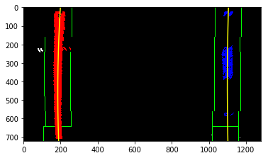

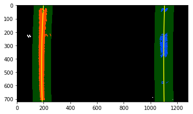

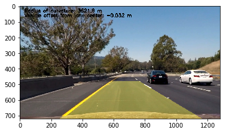

```python
dist_pickle = pickle.load(open(pickle_file,'rb'))
mtx = dist_pickle['mtx']
dist = dist_pickle['dist']
img_file = 'test_images/test6.jpg'
img = mpimg.imread(img_file)
result = process_image(img)
```

Below is the function to generate a full HD 1080 video to show the lane detection and markings. You can view the output of this video in youtube: **https://www.youtube.com/watch?v=3VdODgmWHVM**

```python
def process_video(input_file, output_file):
    #Given input_file video, save annotated video to output_file
    video = VideoFileClip(input_file)
    #annotated_video = video.fl_image(process_image)
    #annotated_video = video.fl_image(process_birdeyeview)
    annotated_video = video.fl_image(multiview)
    annotated_video.write_videofile(output_file, audio=False)
```

```python
process_video('project_video.mp4', 'submit_multiview_with_displayInfo.mp4')
```

## 5. Discussion

While implementing this Advanced Lane Line project, I've faced the issues that the algorithm tried to pick up the unwanted pixels in the middle of the lanes due to the texture of road noises inside the lanes. This caused the lane markings bended and curved unexpectively. To solve this issue, I had to define the ROI region to mask out the road noises inside the lanes as you can see in the **cv2.fillPoly(combined_sobelx_hls_binary, np.array([src], np.int32), 0)** in code block: In[5]

As suggested by the previous mentor, one of the way which I can improve my algorithm is to also try applying thresholds based on the V channel of HSV (for yellow lines) and the L channel of HLS (for white lies). These two color channels can do a nice job of identifying lane lines without getting distracted by shadows and color changes.

Lastly, this algorithm has been calculated based on a lengthy and almost straight road. If this algorithm applies to a narrow twisted and curly road, this algorithm could fail. For such narrow and curly road, I need to apply this algorithm to calculate on near/shorter road view in order to make the algorithm to work again.